# SLDPCA and Residential Markets

King County, WA Analysis

Andy Krause

12/29/2020

## What I Did

- Ran a host of models on King County home sales from 2017 to end of 2019
  - Linear and Random Forest Models
  - Variety of different specifications aimed at teasing out the marginal contribution of the SLD variables
- Extracted measures of impact from each variable in each model
  - Linear = coefficient values
  - Random Forest = Partial Dependency analysis on each SLD variable
- Summarized model performance
  - Model Fit (adj R-squared)
  - Predictive Ability: Median Absolute Percent Error (MdAPE) * Out-of-time prediction on last month in the data
  - Spatial Autocorrelation of Errors (SPAC): Moran’s I Statistic, lower is better
  - Predictive Ability of Sales Near Submarket Boundary (Border MdAPE) ##

## Interpreting the SLD Impact

The plot below shows the impact (in % terms) of each of the SLD variables in four different model specifications:

- Linear (Blue) vs Random Forest (Orange)
- SLD as only spatial variable (Solid Line) vs SLD with X,Y and Submarket Fixed Effects (Dashed)

Broad takeaways:

- SLDs 1, 2 and 4 are positive, 3 and 5 negative
- The magitude of the impacts are greatly reduced when other spatial control features are added, but still remain (other than SLD 4)
- Linear and Random Forest models show similar directionality in all cases and roughly similar magnitude for all SLD variables except SLD 2 where the linear model suggests a much larger impact than the random forest models.
- SLDs 1, 3 and 5 show an ‘S’ curve in the random forest impacts suggesting that even with the standardization the linear model is missing some variation across the spectrum of SLD variable values.

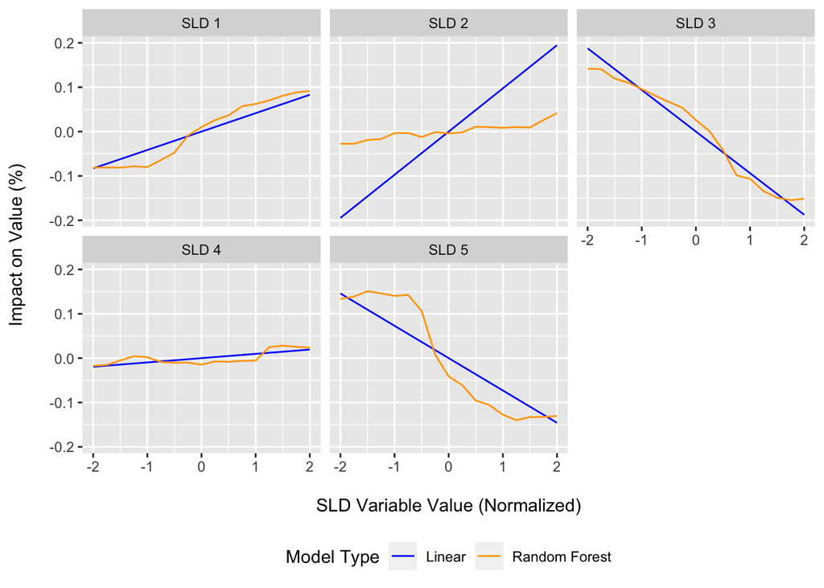

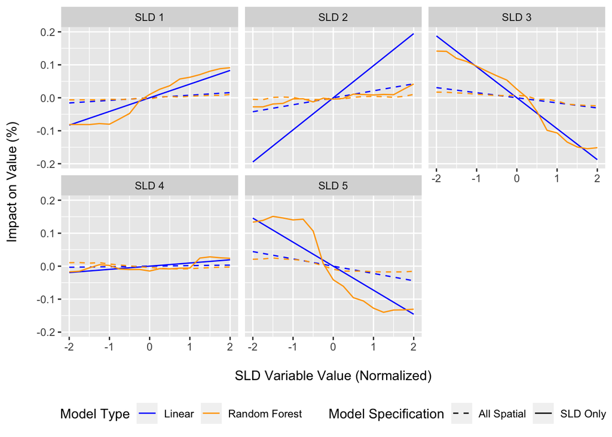

### Model Performance

Next, I looked at how well the SLD features helped a variety of model performance indicators.

Key takeaways:

- Model fit and predictive abilty are highly correlated, will just talk about predictions
- SLD variables don’t add much to model performance in linear model
- Impacts of SLD variables on model performance much more significant in random forest model
- Submarket fixed effects are hard to beat in a linear model
- Submarket fixed effects are much less effective than X,Y coordinates and/or SLD variables in random forest
- All model show significant spatial autocorrelation
- Analysis of Border properties is inconclusive…needs a bit more work here.

| spec | fit | mdape | mdpe | spac | border_mdape |
| --- | --- | --- | --- | --- | --- |
| **Linear Model** |  |  |  |  |  |
| base | 0.513 | 0.204 | 0.016 | 31.4 | 0.240 |
| subm | 0.789 | 0.131 | 0.006 | 16.3 | 0.122 |
| xy | 0.707 | 0.153 | 0.031 | 28.6 | 0.146 |
| sld | 0.570 | 0.189 | 0.024 | 30.7 | 0.209 |
| sld+subm | 0.795 | 0.131 | 0.005 | 15.3 | 0.122 |
| sld+xy | 0.717 | 0.150 | 0.031 | 27.5 | 0.144 |
| sld + xy + subm | 0.803 | 0.131 | 0.006 | 15.3 | 0.120 |
| **Random Forest** |  |  |  |  |  |
| base | 0.606 | 0.178 | 0.033 | 29.0 | 0.194 |
| subm | 0.841 | 0.104 | 0.005 | 11.5 | 0.105 |
| xy | 0.875 | 0.083 | 0.001 | 6.7 | 0.072 |
| sld | 0.821 | 0.092 | -0.005 | 10.0 | 0.100 |
| sld+subm | 0.871 | 0.085 | -0.006 | 4.4 | 0.087 |
| sld+xy | 0.879 | 0.081 | -0.006 | 4.1 | 0.069 |
| sld + xy + subm | 0.883 | 0.081 | -0.008 | 3.4 | 0.070 |